# Household Income

# Household Disposable Income

Household disposable income is a well known indicator of mental well-being (Graham 2009). Estimating this is a crucial instrument for the effects of many policy interventions

The output variable is monthly household disposable income. This is calculated as a composite using several variables. Rent, mortgages, and council tax are subtracted from net household income and adjusted by household size. This value is then adjusted for yearly inflation estimates.

$$hh\_income\_intermediate =
((net\_hh\_income) - (rent + mortgage + council\_tax)) /
oecd\_equivalence\_factor$$
$$hh\_income = hh\_income\_intermediate *
inflation\_factor$$

More information on these variables can be found at the following links:

- [net_monthly_income](https://www.understandingsociety.ac.uk/documentation/mainstage/dataset-documentation/variable/fihhmnnet1_dv)
- monthly_outgoings is the sum of [rent](https://www.understandingsociety.ac.uk/documentation/mainstage/dataset-documentation/variable/rentgrs_dv), [mortgage](https://www.understandingsociety.ac.uk/documentation/mainstage/dataset-documentation/variable/xpmg_dv), and [council tax](https://www.understandingsociety.ac.uk/documentation/mainstage/variables/ctband_dv/).
- [oecd_equivalence_scale](https://www.understandingsociety.ac.uk/documentation/mainstage/dataset-documentation/variable/ieqmoecd_dv)
- See note below about council tax.

This produces a continuous distribution of pounds per month available for a household to spend as it likes. This is plotted below with a median income of $\sim£1650$.

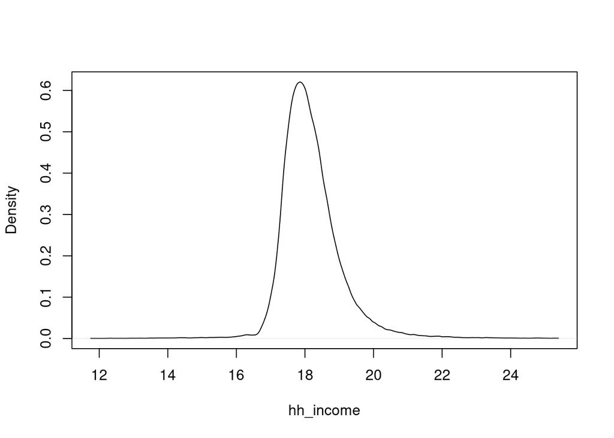

```r
continuous_density(obs)
```

## Transition Model

To estimate this variable we use a Generalised Linear Mixed Model (GLMM) using the [lme4](https://www.rdocumentation.org/packages/lme4/versions/1.1-36) package in R.

Formula:

$$hh\_income \sim hh\_income\_last + age
+ age^2 + age^3 + sex + ethnicity + region + \\education\_state +
job\_sec + SF\_12 + labour\_state + (1|pidp)$$

Each variable included is defined as follows. Each variable with discrete values is defined in the data tables section of this documentation [here](https://leeds-mrg.github.io/Minos/documentation/data_tables.html).

| Predictor | Description | Literature/Justification |
| --- | --- | --- |
| Previous Income | Income in last wave | (Dilmaghani 2018) |
| Sex |  | (Dilmaghani 2018) |
| Age |  |  |
| Ethnicity |  | (Clemens and Dibben 2014) |
| Region | Administrative region of the UK | (Brewer et al. 2007) |
| Education | Highest attained qualification | (Eika, Mogstad, and Zafar 2019) |
| Job NSSEC | 8 level socio-economic employment category | (Clemens and Dibben 2014) |
| SF-12 MCS | Mental wellbeing | (Viswanathan, Anderson, and Thomas 2005) |
| Labour State | Employment status | (Dilmaghani 2018) |

```r
print(summary(model))
```

```
## Generalized linear mixed model fit by maximum likelihood (Adaptive
##   Gauss-Hermite Quadrature, nAGQ = 0) [glmerMod]
##  Family: Gamma  ( log )
## Formula: hh_income_new ~ scale(hh_income) + scale(age) + I(scale(age)^2) +
##     I(scale(age)^3) + factor(sex) + relevel(factor(ethnicity),
##     ref = "WBI") + factor(region) + relevel(factor(education_state),
##     ref = "1") + relevel(factor(job_sec), ref = "3") + scale(SF_12) +
##     relevel(factor(S7_labour_state), ref = "FT Employed") + (1 |      pidp)
##    Data: data
##
##       AIC       BIC    logLik  deviance  df.resid
##  612911.6  613431.7 -306405.8  612811.6    243509
##
## Scaled residuals:
##      Min       1Q   Median       3Q      Max
## -24.4443  -0.3193  -0.0358   0.2881  13.8807
##
## Random effects:
##  Groups   Name        Variance  Std.Dev.
##  pidp     (Intercept) 0.0004159 0.02039
##  Residual             0.0016734 0.04091
## Number of obs: 243559, groups:  pidp, 44786
##
## Fixed effects:
##                                                                     Estimate
## (Intercept)                                                        2.8981772
## scale(hh_income)                                                   0.0160646
## scale(age)                                                         0.0121056
## I(scale(age)^2)                                                    0.0012228
## I(scale(age)^3)                                                   -0.0033185
## factor(sex)Male                                                    0.0005352
## relevel(factor(ethnicity), ref = "WBI")BAN                        -0.0135887
## relevel(factor(ethnicity), ref = "WBI")BLA                        -0.0170216
## relevel(factor(ethnicity), ref = "WBI")BLC                        -0.0131225
## relevel(factor(ethnicity), ref = "WBI")CHI                        -0.0032772
## relevel(factor(ethnicity), ref = "WBI")IND                        -0.0056032
## relevel(factor(ethnicity), ref = "WBI")MIX                        -0.0074393
## relevel(factor(ethnicity), ref = "WBI")OAS                        -0.0124968
## relevel(factor(ethnicity), ref = "WBI")OBL                        -0.0097827
## relevel(factor(ethnicity), ref = "WBI")OTH                        -0.0103478
```

[output cut: 167 more lines]

```
## relevel(factor(job_sec), ref = "3")1                               < 2e-16 ***
## relevel(factor(job_sec), ref = "3")2                               < 2e-16 ***
## relevel(factor(job_sec), ref = "3")4                              6.96e-11 ***
## relevel(factor(job_sec), ref = "3")5                               < 2e-16 ***
## relevel(factor(job_sec), ref = "3")6                              7.86e-11 ***
## relevel(factor(job_sec), ref = "3")7                               < 2e-16 ***
## relevel(factor(job_sec), ref = "3")8                               < 2e-16 ***
## scale(SF_12)                                                       < 2e-16 ***
## relevel(factor(S7_labour_state), ref = "FT Employed")PT Employed   < 2e-16 ***
## relevel(factor(S7_labour_state), ref = "FT Employed")Job Seeking   < 2e-16 ***
## relevel(factor(S7_labour_state), ref = "FT Employed")FT Education  < 2e-16 ***
## relevel(factor(S7_labour_state), ref = "FT Employed")Family Care   < 2e-16 ***
## relevel(factor(S7_labour_state), ref = "FT Employed")Not Working   < 2e-16 ***
## ---
## Signif. codes:  0 '***' 0.001 '**' 0.01 '*' 0.05 '.' 0.1 ' ' 1
```

```
##
## Correlation matrix not shown by default, as p = 48 > 12.
## Use print(summary(model), correlation=TRUE)  or
##     vcov(summary(model))        if you need it
```

### Council Tax

In the UKHLS main release data, [council tax](https://www.understandingsociety.ac.uk/documentation/mainstage/variables/ctband_dv/) information is reported by band. Specific amount deductions are only available in the Special Licence and Secure Access datasets. Instead of reported deductions, we have simulated the amount of council tax each household is paying by taking a random uniform draw for each household within the confines of their band.

## Validation

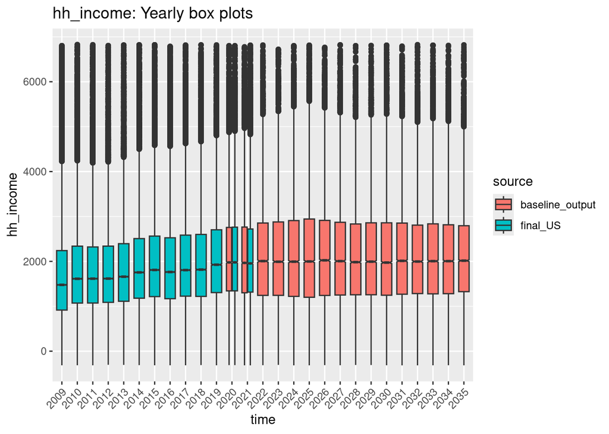

```r
handover_boxplots(raw.dat, base.dat, v)
```

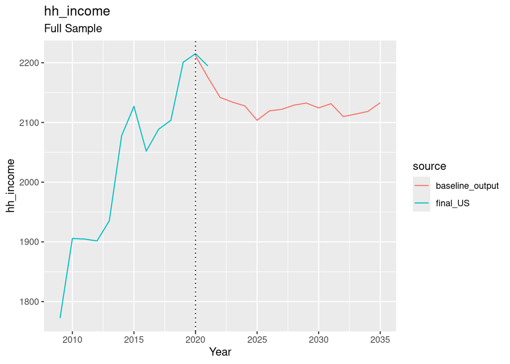

```r
handover_lineplots(raw.dat, base.dat, v)
```

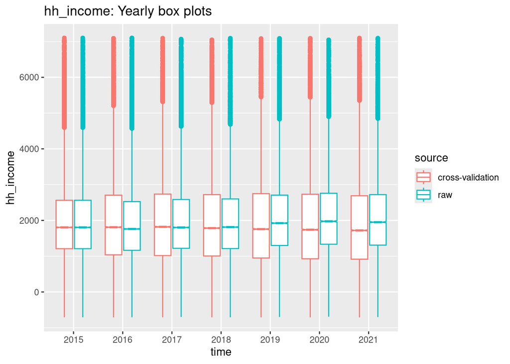

```r
multi_year_boxplots(raw, cv, 'hh_income')
```

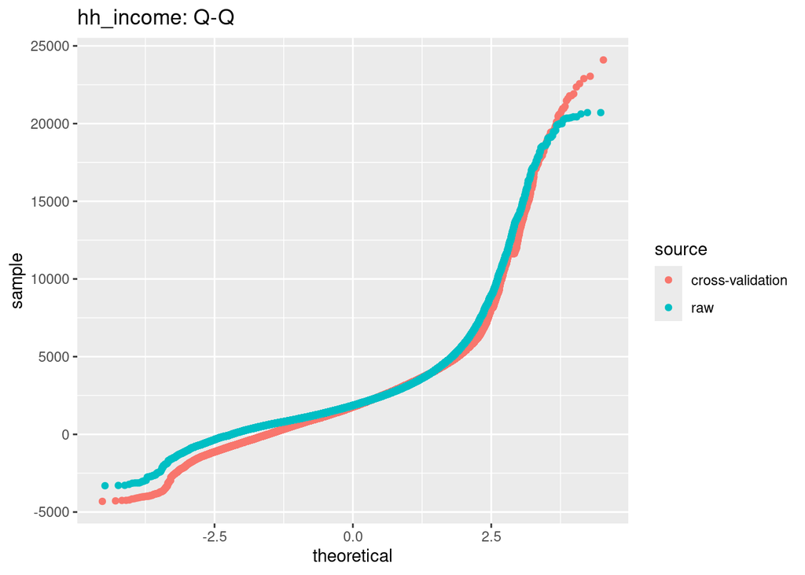

```r
q_q_comparison(raw, cv, 'hh_income')
```

## Results

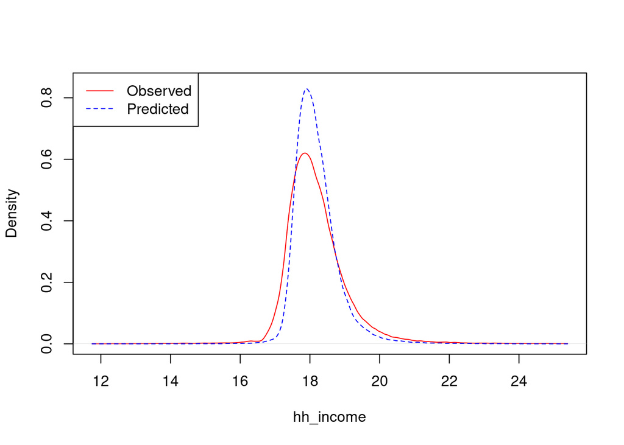

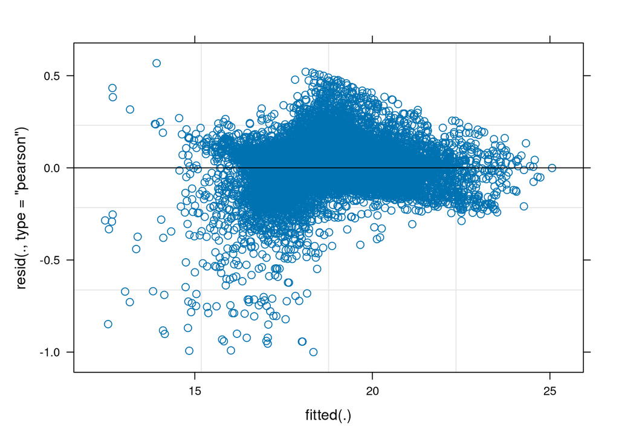

## References

Brewer, Mike, Alastair Muriel, David Phillips, and Luke Sibieta. 2007. “Poverty and Inequality in the UK: 2008.”

Clemens, Tom, and Chris Dibben. 2014. “A Method for Estimating Wage, Using Standardised Occupational Classifications, for Use in Medical Research in the Place of Self-Reported Income.” *BMC Medical Research Methodology* 14 (1): 1–8.

Dilmaghani, Maryam. 2018. “Sexual Orientation, Labour Earnings, and Household Income in Canada.” *Journal of Labor Research* 39 (1): 41–55.

Eika, Lasse, Magne Mogstad, and Basit Zafar. 2019. “Educational Assortative Mating and Household Income Inequality.” *Journal of Political Economy* 127 (6): 2795–835.

Graham, Hilary. 2009. *Understanding Health Inequalities*. McGraw-hill education (UK).

Viswanathan, Hema, Rodney Anderson, and Joseph Thomas. 2005. “Nature and Correlates of SF-12 Physical and Mental Quality of Life Components Among Low-Income HIV Adults Using an HIV Service Center.” *Quality of Life Research* 14 (4): 935–44.